*Note: This was originally part of: the [spatialtest](https://github.com/nickmalleson/spatialtest/) github repository. This file superseeds that one as the code has been tidied up etc.*

# Overview

**Research question**: What is the 'spatial resolution' of different types of crime?

(Or: what is the largest possible spatial resolution that we can use, before aggregation hides important lower-level variation)

(Or: is crime more/less concentrated than other phenomena?)

(Or: repeat the 2011 crime stability paper?)

We know that for many types of crime if you aggregate data to anything larger than a block then you hide important underlying spatial variation, but is this resolution the same for all types of crime? At what point are the diminishing returns of increased spatial resolution take over?

**Method**

- For a number of different of crime types (point patterns), choose two time periods (*can refer to Martin's temporal sppt paper to identify crimes and time periods that are stable*). Then:
1. Aggregate the points to a regular grid
2. Calculate the S-Index (local and global)
3. Shift the grids multiple times in N, E, S, W in order to reduce the impact of MAUP and calculate S-Index again
4. Increase the resolution of the grid, and repeat

**Results**

- Graph the resolution against S-Index for the different crimes (see below)
- At the point where the graph ‘kinks’ you have found the optimal resolution (cells as large as they can go before the differences start to explode).
- (Fuzzy) map of the local S-Index to see where there are differences (i.e. maybe it is more appropriate to change the resolution by area)
- Could also explore the relationship in more detail, e.g. log plots become linear for some crimes? What impact does this have on how they should be analysed? Etc.

**Decisions / for discussion**

- Need to decide on temporal resolution for comparison
  - Need two patterns for which we expect no structural change – i.e. any differences are random.

## Notes on the Multiscale Spatial Error Assessment Method

This is the R implementation and further development of the Multiscale Spatial Error Assessment method (aka [Multiscale Validation](http://www.geog.leeds.ac.uk/courses/other/programming/practicals/general/modelling/validation/multiscale-code/2.html)).

The aim of the method is to take two point-patterns, iteratively aggregate the points to cells of increasing size, and calculate the error between the two data sets at the different grid resoultions. See the right images for an example (from [here](http://www.geog.leeds.ac.uk/courses/other/programming/practicals/general/modelling/validation/multiscale-code/2.html)).

The method has has been used in the following paper:

Malleson, N., A. Heppenstall, L. See, A. Evans (2013) Using an agent-based crime simulation to predict the effects of urban regeneration on individual household burglary risk. *Environment and Planning B: Planning and Design.* 40(3) 405-426. Available [here](http://www.envplan.com/abstract.cgi?id=b38057) and [here](http://nickmalleson.co.uk/wp-content/uploads/2013/05/EPB-V6-forBlog.pdf) (if you don't have access to the journal)

Thanks to Lex Comber and Chris Brunsdon for their excellent book 'R for Spatial Analysis and Mapping'. I got most of the R GIS stuff from there.

Brunsdon, C and Comber, L (2015) *An Introduction to R for Spatial Anaysis and Mapping*. Sage

[figure not shown]

## Configuration and library loading

Configure the script here. (Un)comment or edit lines as appropriate to change the data used and the parameters for the method. (*Note: R code not included in output*).

# Data

## Crime data

We use publicly-available Vancouver crime data, available [here](http://data.vancouver.ca/datacatalogue/crime-data.htm).

Data are available from: http://data.vancouver.ca/datacatalogue/crime-data-details.htm and there is a single zip file: ftp://webftp.vancouver.ca/opendata/shape/crime_shp_all_years.zip.

The script begins by downloading the data (if necessary).

```r
ZIPFILENAME <- "./data-raw/vancouver_public/crime_shp_all_years.zip"

if (!file.exists(ZIPFILENAME)) {
  print("Downloading crime data")
  download.file(url = "ftp://webftp.vancouver.ca/opendata/shape/crime_shp_all_years.zip", destfile = ZIPFILENAME)
}
```

Then read it in:

```r
# Unzip the files into the working directory
zipfile <- unzip(ZIPFILENAME)

# Read the shapefile
all.crime <- readOGR(dsn="./crime_shp_all_years", layer = "crime_shp_all_years")
# Delete the extracted file
unlink(zipfile)
unlink("crime_shp_all_years", recursive = TRUE) # a left over directory

# Assign short codes to crime types (the below throws an error about 'values must be length 1'
# if there are any crime types that aren't matched to short equivalents)
all.crime$TYPE2 <- as.factor(unlist(
  mclapply(X = all.crime$TYPE, FUN = function(t) {
    t2 <- switch(as.character(t),
          "Break and Enter Commercial" = "BNEC",
          "Break and Enter Residential/Other" = "BNER",
          "Mischief" = "MISCHIEF",
          "Other Theft" = "OTHERTHEFT",
          "Theft from Vehicle" = "TFV",
          "Theft of Bicycle" = "TOB",
          "Theft of Vehicle" = "TOV",
          "Vehicle Collision or Pedestrian Struck (with Fatality)" = "COLFAT",
          "Vehicle Collision or Pedestrian Struck (with Injury)" = "COLINJ")
})))

# Drop 2018 (not sufficient data yet)
all.crime <- all.crime[which(all.crime$YEAR<2018),]

rm(ZIPFILENAME)
```

How many different crimes are there, by year:

```r
print(xtable(table(all.crime$TYPE, all.crime$YEAR)), type="html")
```

|  | 2003 | 2004 | 2005 | 2006 | 2007 | 2008 | 2009 | 2010 | 2011 | 2012 | 2013 | 2014 | 2015 | 2016 | 2017 |
| --- | --- | --- | --- | --- | --- | --- | --- | --- | --- | --- | --- | --- | --- | --- | --- |
| Break and Enter Commercial | 3197 | 3283 | 2639 | 2844 | 2436 | 2224 | 1858 | 1657 | 1749 | 1687 | 1774 | 2244 | 2457 | 2686 | 2143 |
| Break and Enter Residential/Other | 6883 | 6538 | 5542 | 5674 | 4996 | 4432 | 3497 | 3270 | 3231 | 3311 | 3025 | 3044 | 3121 | 2995 | 2482 |
| Mischief | 6391 | 5601 | 5062 | 5184 | 4810 | 5276 | 4430 | 4506 | 4828 | 4243 | 4191 | 4518 | 4193 | 4598 | 5333 |
| Other Theft | 2582 | 2605 | 2611 | 2966 | 3024 | 3142 | 3662 | 3432 | 3562 | 3630 | 3488 | 4210 | 4679 | 5708 | 5485 |
| Theft from Vehicle | 17744 | 18204 | 16554 | 14734 | 12226 | 11298 | 10007 | 8612 | 7435 | 8097 | 8340 | 10137 | 10545 | 12816 | 12866 |
| Theft of Bicycle | 1418 | 1230 | 1416 | 1467 | 1203 | 1176 | 1641 | 1668 | 1517 | 1817 | 2034 | 2461 | 3063 | 2635 | 2170 |
| Theft of Vehicle | 6361 | 6102 | 5031 | 3682 | 3305 | 2420 | 1882 | 1467 | 1093 | 1151 | 1034 | 1290 | 1371 | 1478 | 1492 |
| Vehicle Collision or Pedestrian Struck (with Fatality) | 24 | 22 | 32 | 20 | 24 | 17 | 14 | 10 | 11 | 18 | 15 | 13 | 14 | 15 | 12 |
| Vehicle Collision or Pedestrian Struck (with Injury) | 1803 | 1868 | 1984 | 1384 | 1237 | 1185 | 1278 | 1327 | 1262 | 1474 | 1485 | 1575 | 1669 | 1699 | 1391 |

Do a graph as well, indexed to volume at the start

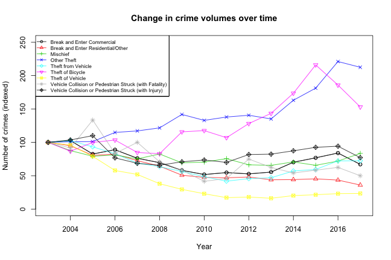

```r
crime.table <- table(all.crime$TYPE, all.crime$YEAR)
crime.types <- rownames(crime.table)
crime.years <- sapply(X = colnames(crime.table), FUN = strtoi)

for ( i in 1:length(crime.types)) {
  type <- crime.types[i]

  # Need to index
  start <- crime.table[type,1]
  yval <- 100 * ( crime.table[type,] / start)
  if (i==1) {
    plot(x=crime.years, y=yval, type='o', lty=1, pch=i, col=i, ylim=c(0,250),
         main="Change in crime volumes over time", ylab="Number of crimes (indexed)", xlab="Year"
         )
  }
  lines(x=crime.years, y=yval, type='o', lty=1, pch=i, col=i)
  legend("topleft", legend = crime.types, col=1:length(crime.types), lty=1, pch=1:length(crime.types), cex=0.7)
}
```

```r
rm(start, yval, type)
```

For context, see how many there are in total (using short names of crimes)

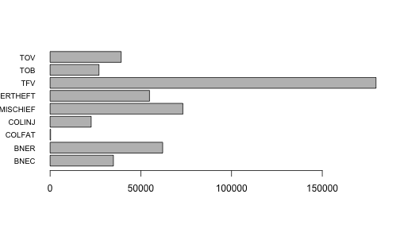

```r
barplot(rowSums(table(all.crime$TYPE2, all.crime$YEAR)
), horiz=TRUE, cex.names=0.8, las=1)
```

Split the big file up into different crimes and time periods

```r
# A directory for the crime data (in case it doesn't exist)
dir.create(file.path("./ROUT", "crime"), showWarnings = FALSE)

# Shorter versions of the crime types
crime.types2 <- unique(all.crime$TYPE2)

for (type in crime.types2) {
  assign(as.character(type), all.crime[all.crime$TYPE2==type,])
  # Write them as well as they can be useful later
  writeOGR(all.crime[all.crime$TYPE2==type,], dsn = "./ROUT/crime", layer = type,
           driver = "ESRI Shapefile", overwrite_layer = TRUE)
}
```

## Areas data

Finally we need some administrative boundaries. In the analysis we want to mask cells that aren't over land as these will distort the results. These boundaries are also useful in displaying the results.

```r
vancouver.boundaries <- readOGR(dsn="data-raw/vancouver_all", layer = "areas")
```

# The Multi-Scale Error Assessment Method (MSEA)

The method works as follows:

1. Aggregate the points to a regular grid
2. Calculate the S-Index (local and global) (as well as some other statistics)
3. Shift the grids multiple times in N, E, S, W in order to reduce the impact of MAUP and calculate S-Index again
4. Increase the resolution of the grid, and repeat

The following defines a function that will run the method (*the R code has been hidden from the output because it is so long*).

# Results

## Run the MSEA

Note that when zeros are included in the analysis, the similarity of the comparison increases. This is because there will be many cells with no crimes, hence the *same number* of crimes (0). However, when we examine the graph of resolution against similarity, the shape of the graphs is identical so, importantly, the 1st derivatives are identical. This means that in the later analysis it doesn't matter whether cells with zero counts are included or not as we will always find the same 'elbow'/kink in the graph. This can be verified by running an earlier version of this file that included cells with and without zero:

- https://github.com/nickmalleson/sppt/blob/2692a3676fa6c58f9041b637b0f649ec4cc0b908/spatial_resolution.Rmd

In the subsequent analysis cells with no crimes will be included.

Run the MSEA algorithm on BNER, BNEC, TFV and TOB, comparing 2015 and 2016.

```r
# Put the data into lists so I don't have to do too much repeating

data1 <- list("base" = BNER[BNER$YEAR==2015,], "test"= BNER[BNER$YEAR==2016,], name="BNER")
data2 <- list("base" = BNEC[BNEC$YEAR==2015,], "test"= BNEC[BNEC$YEAR==2016,], name="BNEC")
data3 <- list("base" = TFV[TFV$YEAR==2015,], "test"= TFV[TFV$YEAR==2016,], name="TFV")
data4 <- list("base" = TOB[TOB$YEAR==2015,], "test"= TOB[TOB$YEAR==2016,], name="TOB")
all <- list(data1, data2, data3, data4)
all.boot <- list(data1, data2, data3, data4) # Versions for the new types of sppt test
all.diff <- list(data1, data2, data3, data4)

rm(data1, data2, data3, data4)

N <- 50
N.SHIFTS <- 10
STEP <- 1

# (for testing )
#y <- msea(data1[["base"]], data1[["test"]], N=20, n.shifts=1, step=1, mask=vancouver.boundaries,
#          ignore.zeros = F, return.sobject=TRUE,return.grids=TRUE,
#          run.parallel = FALSE, sppt_diff, adj = "none")

# Begin with the old sppt
tmp <- lapply(X = all, FUN = function(x) { # No longer do these in parallel as the method itself has been parallelised
  msea(x[['base']], x[['test']], N=N, n.shifts=N.SHIFTS, mask=vancouver.boundaries,
       ignore.zeros = F, step=STEP,
       return.sobject=FALSE, # Don't return the s.objects, nor the spatial grids
       return.grids=FALSE,   # to save memory
       sppt_func = sppt # the kind of sppt function to run
  ) })#, mc.preschedule=FALSE, mc.allow.recursive=TRUE)
stopifnot(length(tmp)==4)
# Store the results in the lists in an item called 'r'
for (i in 1:length(tmp)) {
  all[[i]][['r']] <- tmp[[i]]
}
rm(tmp)
gc() # Do some garbage collection after deleting the big temporary objects (maybe not necessary)
```

```
##           used (Mb) gc trigger  (Mb) max used  (Mb)
## Ncells 1643395 87.8    5295264 282.8  8273852 441.9
## Vcells 9296102 71.0   20439317 156.0 20439302 156.0
```

```r
# Now the bootstrap version
tmp <- lapply(X = all, FUN = function(x) {
  msea(x[['base']], x[['test']], N=N, n.shifts=N.SHIFTS, mask=vancouver.boundaries,
       ignore.zeros = F, step=STEP,
       return.sobject=FALSE, return.grids=FALSE, sppt_func = sppt_boot
  ) })
stopifnot(length(tmp)==4)
# Store the results in the lists in an item called 'r'
for (i in 1:length(tmp)) {
  all.boot[[i]][['r']] <- tmp[[i]]
}
rm(tmp)
gc() # Do some garbage collection after deleting the big temporary objects (maybe not necessary)
```

```
##           used (Mb) gc trigger  (Mb) max used  (Mb)
## Ncells 1645828 87.9    5295264 282.8  8273852 441.9
## Vcells 9320238 71.2   20439317 156.0 20439302 156.0
```

```r
# Finish with the difference in proportions
tmp <- lapply(X = all, FUN = function(x) {
  msea(x[['base']], x[['test']], N=N, n.shifts=N.SHIFTS, mask=vancouver.boundaries,
       ignore.zeros = F, step=STEP, return.sobject=FALSE, return.grids=FALSE,
       sppt_func = sppt_diff, adj = "none", test="Fisher" # (note additional argument to sppt_diff)
  ) })
stopifnot(length(tmp)==4)
# Store the results in the lists in an item called 'r'
for (i in 1:length(tmp)) {
  all.diff[[i]][['r']] <- tmp[[i]]
}
rm(tmp)
gc() # Do some garbage collection after deleting the big temporary objects (maybe not necessary)
```

```
##           used (Mb) gc trigger  (Mb) max used  (Mb)
## Ncells 1648044 88.1    5295264 282.8  8273852 441.9
## Vcells 9345693 71.4   20439317 156.0 20439302 156.0
```

```r
# save.image('temp.RData') # In case it crashes later
```

Run again for BNER, but this time using *all* available point data. This will be used to see whether we are hitting small number problems with the smaller cells, rather than the legitimate impact of the resolution.

Just use the `sppt_diff` for now. We can compare others later if this is important.

```r
# Sample 50% of the points
s <- sample(seq_along(BNER), size=round(nrow(BNER)/2), replace=FALSE)
p1 <- BNER[s,]
p2 <- BNER[-s,]
stopifnot(nrow(p1) + nrow(p2) == nrow(BNER))

bner.result.largesample <-
  msea(p1, p2, N=N, n.shifts=N.SHIFTS, mask=vancouver.boundaries, ignore.zeros = F, step=STEP,
       return.sobject=FALSE, return.grids=FALSE, sppt_func = sppt_diff, adj = "none" # (note additional argument to sppt_diff)
       )

rm(s) # tidy up
```

Also run again once for BNER and TOB to do the fuzzy mapping. These results wont be used in the graph, so don't need to calculate the index as many times. Also write out the results as a csv file. Note that some specific grids are written out by the chunk `map.iterations` once it has been decided which grids are the most interesting.

```r
N <- 50
N.SHIFTS <- 1
STEP <- 1
p1 <- BNER[BNER$YEAR==2015,]
p2 <- BNER[BNER$YEAR==2016,]
bner.result.diff <- msea(points1 = p1, points2 = p2,
                    N=N, n.shifts=N.SHIFTS, mask=vancouver.boundaries, ignore.zeros = F, step=STEP,
                    return.sobject=TRUE, return.grids=TRUE,
                    sppt_func = sppt_diff, adj = "none" # (note additional argument to sppt_diff)
)
p1 <- TOB[TOB$YEAR==2015,]
p2 <- TOB[TOB$YEAR==2016,]
tob.result.diff <- msea(points1 = p1, points2 = p2,
                    N=N, n.shifts=N.SHIFTS, mask=vancouver.boundaries, ignore.zeros = F, step=STEP,
                    return.sobject=TRUE, return.grids=TRUE,
                    sppt_func = sppt_diff, adj = "none" # (note additional argument to sppt_diff)
)

rm(p1, p2) # tidy up

# Delete old files, including some shapefiles that are created  later in chunk map.iterations
files <- list.files(path = "./ROUT", pattern = "bner_result")
for (f in files) { file.remove(paste0("./ROUT/",f)) }
files <- list.files(path = "./ROUT", pattern = "tob_result")
for (f in files) { file.remove(paste0("./ROUT/",f)) }

# Write a csv file with the data in it. THe messy bit is to get all list names except for the results grids
# and s.objects (don't want to try to write those to csv!)
write.csv( data.frame(sapply(
  X=names(tob.result.diff)[names(tob.result.diff)!="results" & names(tob.result.diff)!="s.object"],
  FUN = function(x) { tob.result.diff[[x]] } )),
  file="./ROUT/tob_result_diff.csv"
)

write.csv( data.frame(sapply(
  X=names(bner.result.diff)[names(bner.result.diff)!="results" & names(bner.result.diff)!="s.object"],
  FUN = function(x) { bner.result.diff[[x]] } )),
  file="./ROUT/bner_result_diff.csv"
)



#save.image('temp.RData')
```

Quick test: if we do the analysis with more points, we should see the elbow occur later, and higher Global S values

```r
S <- 5 # Num shifts

# DIFF

temp.bner.diff.small <- msea(
  points1 = BNER[BNER$YEAR==2015,],
  points2 = BNER[BNER$YEAR==2016,],
  N=40, n.shifts=S, mask=vancouver.boundaries, ignore.zeros = F, step=STEP, return.sobject=TRUE, return.grids=TRUE,
  sppt_func = sppt_diff, adj = "none" # (note additional argument to sppt_diff)
  )
gc()
```

```
##            used  (Mb) gc trigger  (Mb) max used  (Mb)
## Ncells  8774316 468.6   12002346 641.0  8791466 469.6
## Vcells 16807646 128.3   29199015 222.8 21268560 162.3
```

```r
temp.bner.diff.large <- msea(
  points1 = BNER[BNER$YEAR==2016 | BNER$YEAR==2014 | BNER$YEAR==2012 | BNER$YEAR==2010 | BNER$YEAR==2008,],
  points2 = BNER[BNER$YEAR==2015 | BNER$YEAR==2013 | BNER$YEAR==2011 | BNER$YEAR==2009 | BNER$YEAR==2007,],
  N=40, n.shifts=S, mask=vancouver.boundaries, ignore.zeros = F, step=STEP, return.sobject=TRUE, return.grids=TRUE,
  sppt_func = sppt_diff, adj = "none" # (note additional argument to sppt_diff)
  )
gc()
```

```
##            used  (Mb) gc trigger   (Mb) max used  (Mb)
## Ncells 15372595 821.0   20885653 1115.5 15389670 821.9
## Vcells 27015745 206.2   42222581  322.2 34781737 265.4
```

```r
# NORMAL

temp.bner.norm.small <- msea(
  points1 = BNER[BNER$YEAR==2015,],
  points2 = BNER[BNER$YEAR==2016,],
  N=40, n.shifts=S, mask=vancouver.boundaries, ignore.zeros = F, step=STEP, return.sobject=TRUE, return.grids=TRUE,
  sppt_func = sppt )
gc()
```

```
##            used   (Mb) gc trigger   (Mb) max used   (Mb)
## Ncells 22526501 1203.1   30163339 1610.9 22543910 1204.0
## Vcells 38079227  290.6   60976516  465.3 45693292  348.7
```

```r
temp.bner.norm.large <- msea(
  points1 = BNER[BNER$YEAR==2016 | BNER$YEAR==2014 | BNER$YEAR==2012 | BNER$YEAR==2010 | BNER$YEAR==2008,],
  points2 = BNER[BNER$YEAR==2015 | BNER$YEAR==2013 | BNER$YEAR==2011 | BNER$YEAR==2009 | BNER$YEAR==2007,],
  N=40, n.shifts=S, mask=vancouver.boundaries, ignore.zeros = F, step=STEP, return.sobject=TRUE, return.grids=TRUE,
  sppt_func = sppt )
gc()
```

```
##            used   (Mb) gc trigger   (Mb) max used   (Mb)
## Ncells 29121768 1555.3   36236006 1935.3 29225087 1560.8
## Vcells 48278290  368.4   73251819  558.9 60976207  465.3
```

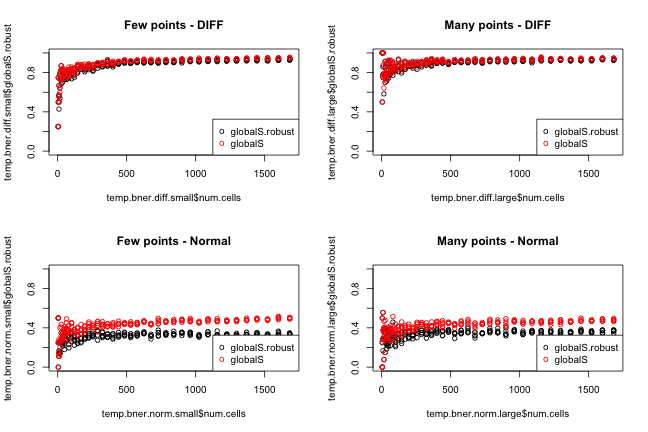

```r
# PLOT

par(mfrow=c(2,2))

# DIFF

# Small (few)
plot(  temp.bner.diff.small$num.cells, temp.bner.diff.small$globalS.robust, ylim=c(0,1), main="Few points - DIFF")
points(temp.bner.diff.small$num.cells, temp.bner.diff.small$globalS, ylim=c(0,1), col="red")
legend("bottomright", legend=c("globalS.robust", "globalS"), pch='o', col=c("black", "red"))

# Large (many)
plot(  temp.bner.diff.large$num.cells, temp.bner.diff.large$globalS.robust, ylim=c(0,1), main="Many points - DIFF")
points(temp.bner.diff.large$num.cells, temp.bner.diff.large$globalS, ylim=c(0,1), col="red")
legend("bottomright", legend=c("globalS.robust", "globalS"), pch='o', col=c("black", "red"))

# NORMAL

plot(  temp.bner.norm.small$num.cells, temp.bner.norm.small$globalS.robust, ylim=c(0,1), main="Few points - Normal")
points(temp.bner.norm.small$num.cells, temp.bner.norm.small$globalS, ylim=c(0,1), col="red")
legend("bottomright", legend=c("globalS.robust", "globalS"), pch='o', col=c("black", "red"))

# Large (many)
plot(  temp.bner.norm.large$num.cells, temp.bner.norm.large$globalS.robust, ylim=c(0,1), main="Many points - Normal")
points(temp.bner.norm.large$num.cells, temp.bner.norm.large$globalS, ylim=c(0,1), col="red")
legend("bottomright", legend=c("globalS.robust", "globalS"), pch='o', col=c("black", "red"))
```

```r
#write.csv(cbind(temp.bner.diff.large$iteration, temp.bner.diff.large$num.cells, temp.bner.diff.large$globalS, temp.bner.diff.small$globalS), file="~/Desktop/temp.csv")

#write.csv(temp.bner.diff.large$results[[5]]@data, file="~/Desktop/large_05.csv" )
#write.csv(temp.bner.diff.large$results[[39]]@data, file="~/Desktop/large_39.csv" )
#write.csv(temp.bner.diff.small$results[[5]]@data, file="~/Desktop/small_05.csv" )
#write.csv(temp.bner.diff.small$results[[39]]@data, file="~/Desktop/small_39.csv" )
```

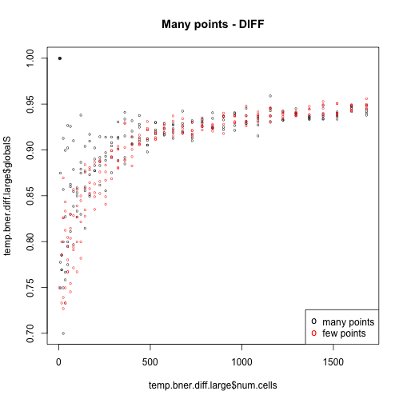

```r
# Large (many)
plot(  temp.bner.diff.large$num.cells, temp.bner.diff.large$globalS, ylim=c(0.7,1), main="Many points - DIFF", pch="o", cex=0.5)
points(temp.bner.diff.small$num.cells, temp.bner.diff.small$globalS, ylim=c(0,1), col="red", pch="o", cex=0.5)
legend("bottomright", legend=c("many points", "few points"), col=c("black", "red"), pch="o", cex=1)
```

```r
errors.temp <- c("rss", "r.squared", "rmse", "globalS", "globalS.robust", "mean.similarity", "mean.similarity.robust") # The error stats. to use
options(scipen=1) # A bit of scientific notation is OK
r <- bner.result.diff
#r <- tob.result.diff

plots <- list()
plot.count <- 1

for (e in errors.temp) {
  x <- r$num.cells
  y <- r[[e]]
  the.plot <- ggplot(data = data.frame("x"=x, "y"=y ), mapping = aes(x,y)) +
        geom_point(size=0.1, color="black") +
        #geom_hex(bins=15, show.legend = FALSE) +
        geom_smooth(method="loess", se=TRUE, level=0.99 )+ #, color="red") +
        ylab(paste("Error (",e,")"))+
        xlab("Number of Cells")+
        ggtitle(paste0("BNER",", ",e))
     plots[[plot.count]] <- the.plot
     plot.count <- plot.count + 1
}


do.call("grid.arrange", c(plots, ncol=len(errors.temp)))
```

[output not shown]

```r
rm(errors.temp)
```

## Spatial Error Resolution

Graph the differences, using the number of cells used, for each crime type.

It's a little odd that the RSS and RMSE values decrease with the number of cells. They measure error, so I'd expect them to increase. That said it is likely that the increasing number of zeros will artifically reduce them.

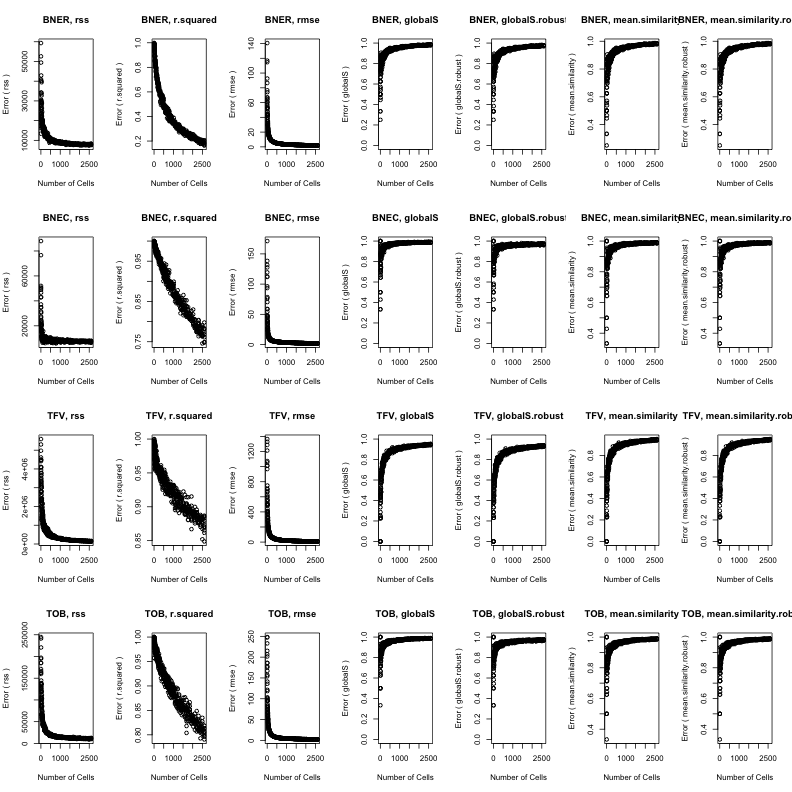

```r
options(scipen=1) # A bit of scientific notation is OK
error.stats <- c("rss", "r.squared", "rmse", "globalS", "globalS.robust", "mean.similarity", "mean.similarity.robust") # The error stats. to use
par(mfrow=c(length(all),length(error.stats))) # One plot for each error statistic

for (a in all.diff) {
  r <- a$r # This is the results of the msea test
  name <- a$name # This is the name of the crime type

  for (e in error.stats) {
    if (is.null(r[[e]])) {
      plot(1,1, col="red", main=paste0("Error. Statistic:\n'",e, "' not found"))
    } else {
      x <- r$num.cells
      y <- r[[e]]
      ylim <- if (e=="globalS" | e=="globalS.robust") c(0,1) else NULL
      plot(x,y, main=paste0(name,", ",e), xlab="Number of Cells", ylab=paste("Error (",e,")"), ylim=ylim)

    }
  }
}
```

```r
options(scipen=1) # A bit of scientific notation is OK
plots = list()
plot.count <- 1

for (i in 1:length(all.diff)) {

  a <- all.diff[[i]]
  r <- a$r # This is the results of the msea test
  name <- a$name # This is the name of the crime type

  for (e in error.stats) {
     x <- r$num.cells
     y <- r[[e]]
     the.plot <- ggplot(data = data.frame("x"=x, "y"=y ), mapping = aes(x,y)) +
        geom_point(size=0.1, color="black") +
        #geom_hex(bins=15, show.legend = FALSE) +
        geom_smooth(method="loess", se=TRUE, level=0.99 )+ #, color="red") +
        ylab(paste("Error (",e,")"))+
        xlab("Number of Cells")+
        ggtitle(paste0(name,", ",e))
     plots[[plot.count]] <- the.plot
     plot.count <- plot.count + 1
  }
}

do.call("grid.arrange", c(plots, ncol=len(error.stats)))
```

[output not shown]

```r
#g <- grid.arrange(plot1, plot2, nrow=2)
```

### Graphs for ECCA - examining Global S Index changes

Graph each crime as a separate plot

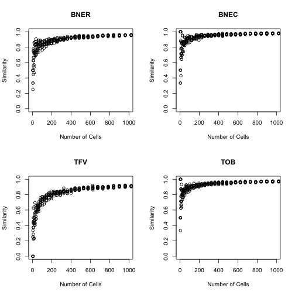

```r
# Make some lists so that the same plotting code can loop
crime.types = vapply(X=all, FUN=function(x)x$name, FUN.VALUE = character(1)) # The crime types (4)



#s.type = "globalS.robust" # Whether to use robust or non-robust
s.type = "globalS"

par(mfrow=c(2,2)) # One plot for each crime type

for (i in 1:length(crime.types)) { # For each crime type
  crime.type <- crime.types[i]
  r <- all.diff[[i]]$r # This is the results of the test for the crime type
  x <- r[["num.cells"]]
  y <- r[[s.type]] # The S Index (either normal or robust)

  plot(x,y, main=paste0(crime.type), xlab="Number of Cells", ylab="Similarity",  ylim=c(0,1), xlim=c(0,1000))
}
```

Try again with confidence intervals

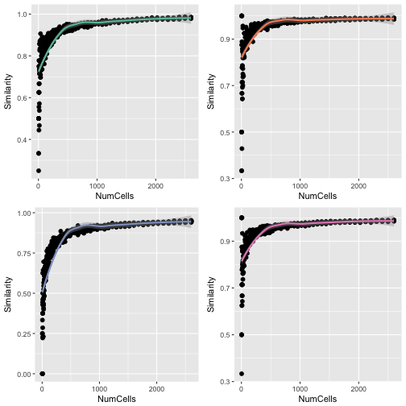

```r
# Make some lists so that the same plotting code can loop
crime.types = vapply(X=all, FUN=function(x)x$name, FUN.VALUE = character(1)) # The crime types (4)

colours  <- brewer.pal(4, "Set2") # Colours for the points

#s.type = "globalS.robust" # Whether to use robust or non-robust
s.type = "globalS"

plots = list()

for (i in 1:length(crime.types)) { # For each crime type
  crime.type <- crime.types[i]
  r <- all.diff[[i]]$r # This is the results of the test for the crime type
  x <- r[["num.cells"]]
  y <- r[[s.type]] # The S Index (either normal or robust)
  df = data.frame("NumCells"=r[["num.cells"]], "Similarity"=r[[s.type]] )

  plots[[i]] <- ggplot(df, aes(NumCells, Similarity)) +
    #geom_hex(bins=20) +
    geom_point(size=2) +
    #guides(colour=guide_legend(title="Sensor")) + # Change the title of the legend
    #geom_smooth(se=TRUE, level=0.99)
    geom_smooth(method="loess", se=TRUE, level=0.99, color=colours[i])

    #scale_colour_manual(values=cols)+
    #ylab("Number of people")+
    #xlab("Hour")
}

#plots[[1]]

grid.arrange(plots[[1]],plots[[2]],plots[[3]], plots[[4]], nrow=2, ncol=2)
```

Graph them all on the same plot

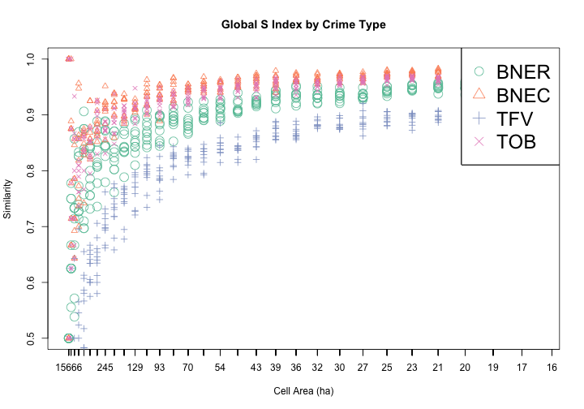

```r
# Make some lists so that the same plotting code can loop
crime.types = vapply(X=all, FUN=function(x)x$name, FUN.VALUE = character(1)) # The crime types (4)
colours  <- brewer.pal(4, "Set2") # Colours for the points


#s.type = "globalS.robust" # Whether to use robust or non-robust
s.type = "globalS"

par(mfrow=c(1,1)) # One plot for each crime type

for (i in 1:length(crime.types)) { # For each crime type
  crime.type <- crime.types[i]
  r <- all.diff[[i]]$r # This is the results of the test for the crime type
  x <- r[["num.cells"]]
  y <- r[[s.type]] # The S Index (either normal or robust)
  if (i==1) {
    plot(x,y, main="Global S Index by Crime Type", xlab="Cell Area (ha)", ylab="Similarity",
           xlim=c(0,1000), ylim=c(0.5,1), col=colours[i], pch=i, cex=2, xaxt='n')
    #axis(1, at=x, labels=r[["num.cells"]])
    axis(1, at=x, labels=round(r[["cell.areas"]]/10000) )

  } else {
    points(x,y, col=colours[i], pch=i)
  }
  legend("topright", legend = crime.types,  pch=1:length(crime.types), col = colours, cex=2)

}
```

### Comparing different Local S Index results

Above we computed the S Index using the 'normal' method, as well as the new 'bootstrap' (`sppt_boot`) and 'proportional difference' (`sppt_diff`). Compare the results for each crime type now using the non-robust index. Also mark on the graphs the points at which I will draw the maps below

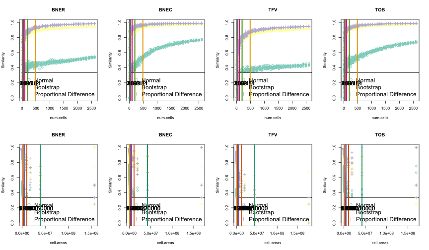

```r
ITERATIONS.TO.MAP <- c(15, 30, 50, 80, 120, 200)

# Make some lists so that the same plotting code can loop
crime.types = vapply(X=all, FUN=function(x)x$name, FUN.VALUE = character(1)) # The crime types (4)
test.results = list(all, all.boot, all.diff)
colours  <- brewer.pal(3, "Set3") # Colours for the points
line.colours <- brewer.pal(length(ITERATIONS.TO.MAP), "Dark2") # Colours for the horizontal lines
names <- c("Normal", "Bootstrap", "Proportional Difference")



#s.type = "globalS.robust" # Whether to use robust or non-robust
s.type = "globalS"

par(mfrow=c(2,length(crime.types))) # 2 rows, one for num.cells and square.area, 4 columns (one for each crime type)

do.s.plot <- function(x.axis.type, s.type = "globalS", xlim=NULL, iter.to.map = ITERATIONS.TO.MAP, text.size=1.5) {
  # Loop for num.cells graphs first (could do the x axis type in another loop, but the graphs are quite difference
  # so this is more hassle than it's worth)
  for (i in 1:length(crime.types)) { # For each crime type
    crime.type <- crime.types[i]
    for (j in 1:length(test.results)) { # For each test result
      error.type <- names[j]
      colour <- colours[j]
      r <- test.results[[j]][[i]]$r # This is the results of the test for the crime type
      x <- r[[x.axis.type]] #num.cells or cell.areas
      y <- r[[s.type]] # The S Index (either normal, boot, or prop)
      if (j==1) {
        plot(x,y, main=paste0(crime.type), xlab=x.axis.type, ylab="Similarity",
            pch=j, ylim=c(0,1), xlim=xlim, col=colour )
        legend("bottomright", legend = names,  pch=1:length(crime.types), col = colours, cex=text.size)
      } else {
        points(x,y, pch=j,  col=colour)
      }
      # Add the straight lines showing where we'll map
      col.count <- 1
      for (iter in iter.to.map) {
        xval = r[[x.axis.type]][iter]
        abline(v = xval, col=line.colours[col.count], lty="solid", lwd=2)
        text  (x = xval, y=0.2, cex=text.size,
               labels=paste0(signif(xval, 4)))
              #labels=paste0(iter,"\n",signif(xval, 4)))
        col.count <- col.count + 1
      }
    }
  }
}

do.s.plot("num.cells")
do.s.plot("cell.areas")
```

Repeat with narrower x axes.

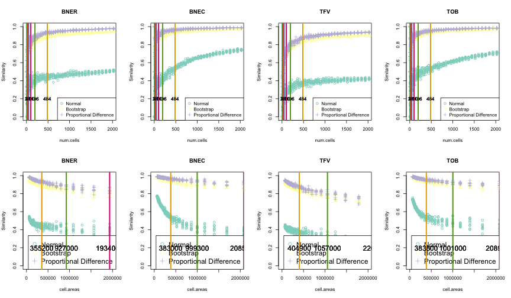

```r
par(mfrow=c(2,length(crime.types))) # 2 rows, one for num.cells and square.area, 4 columns (one for each crime type)
do.s.plot("num.cells", xlim=c(0,2000), text.size=1)
do.s.plot("cell.areas", xlim=c(0,2000000))
```

Even narrower.

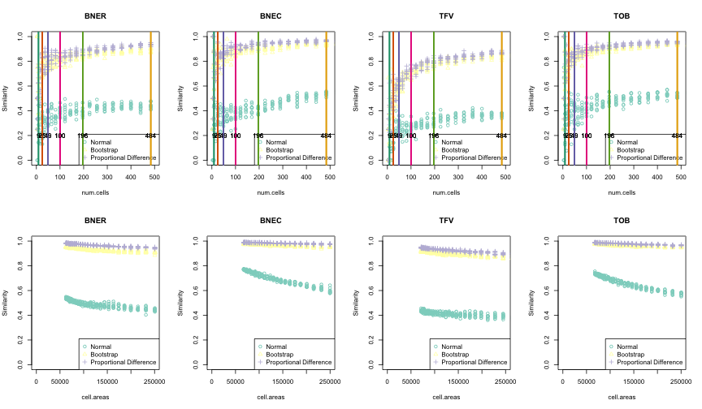

```r
par(mfrow=c(2,length(crime.types))) # 2 rows, one for num.cells and square.area, 4 columns (one for each crime type)
do.s.plot("num.cells", xlim=c(0,500), text.size = 1)
do.s.plot("cell.areas", xlim=c(0,250000), text.size = 1)
```

### Mapping the 'interesting' resolutions

Looking at the maps above, it would be useful to see what each resolution looks like in practice. How large are these cells?

Using the BNER and TOB examples created earlier, map these resolutions.

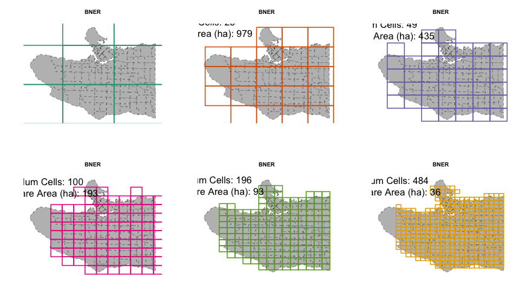

```r
# Code is slightly complicated because the BNER and TOB results aren't as comprehensive as the all, all.boot and all.diff
# ones. This is because for the main results (all*) I don't return the for each iteration because it takes up too much
# memory. So the code below finds the most suitable BNER and TOB results from those that are available (i.e. the nearest
# to the ones listed in ITERATIONS.TO.MAP). It's basically translating from one index to another.

# Find the closest indices for the iterations that we want to map. Need the equivalent number of cells for each iteration
# NOTE: all[[1]] gives results for first crime type. This is OK as all four types have same numbers of cells per iteration:
# sapply(X=seq(1:length(crime.types)), FUN=function(i) all[[i]]$r$num.cells)
num.cells.list <- all[[1]]$r$num.cells
num.cells.to.map <- num.cells.list[ITERATIONS.TO.MAP] # Want to map iterations that has this many cells.
# Find the closest indices (i.e. those that have the number of cells that are the most simlar to the iterations in ITER.TO.MAP)
indices.to.map <- sapply(X=num.cells.to.map, FUN=function(x) {
  i <- min(which(bner.result.diff$num.cells - x >= 0))
  if (is.infinite(i) ){
    # need to check for infinites. This happens when there isn't a large enough grid available.
    # Just return the biggest available (i.e. the index of the last grid)
    return (length(bner.result.diff$num.cells))
  } else {
    return (i)
  }
  })

par(mfrow=c(2,3)) # Assuming six iterations to map
options(scipen=10)
count <- 1
for (index in indices.to.map) {
  num.cells <- bner.result.diff[["num.cells"]][index]
  sq.area <- bner.result.diff[["cell.areas"]][index] / 10000 # hectares
  grid <- bner.result.diff[["results"]][[index]]
  plot(vancouver.boundaries, main=paste0("BNER"), lwd=0.5, col="gray", lty='dashed')
  plot(grid, border=line.colours[count], lwd=2, add=T )
  text(x=grid@bbox["x", "min"], y=grid@bbox["y", "max"], cex=2,
       labels = paste0("Num Cells: ",num.cells, "\nSquare Area (ha): " ,round(sq.area)) )
  #print(bner.result.diff[["results"]][[index]])


  # Also write out the grids as shapefiles (old ones have already been deleted by chunk runMSEA-bner)
  writeOGR(obj = tob.result.diff$results[[index]], dsn = "./ROUT", layer = paste0("tob_result_diff_",count),
           driver = "ESRI Shapefile", overwrite_layer = TRUE, verbose = FALSE)
  writeOGR(obj = bner.result.diff$results[[index]], dsn = "./ROUT", layer = paste0("bner_result_diff_",count),
           driver = "ESRI Shapefile", overwrite_layer = TRUE, verbose = FALSE)

  count <- count + 1
}
```

```r
# The leaflet way:
# cols=c("#FF0000","#00FF00", "#00FF00","#0000FF") # r,g, b
# WEIGHT <- 2
# leaflet() %>%
# addPolygons( data = spTransform(x = bner.result.diff[["results"]][[1]], CRS("+init=epsg:4326") ),
#              col=cols[1], fill=FALSE, weight=WEIGHT) %>%
# addPolygons( data = spTransform(x = bner.result.diff[["results"]][[2]], CRS("+init=epsg:4326") ),
#              col=cols[2], fill=FALSE, weight=WEIGHT) %>%
# addPolygons( data = spTransform(x = bner.result.diff[["results"]][[3]], CRS("+init=epsg:4326") ),
#              col=cols[3], fill=FALSE, weight=WEIGHT) %>%
# addPolygons( data = spTransform(x = bner.result.diff[["results"]][[4]], CRS("+init=epsg:4326") ),
#              col=cols[4], fill=FALSE, weight=WEIGHT) %>%
# addTiles() #%>%  # Add default OpenStreetMap map tiles
#   #addCircles()
```

Zoom in on downtown

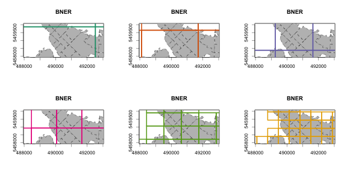

```r
par(mfrow=c(2,3)) # Assuming six iterations to map
options(scipen=10)
count <- 1
for (index in indices.to.map) {
  num.cells <- bner.result.diff[["num.cells"]][index]
  sq.area <- bner.result.diff[["cell.areas"]][index] / 10000 # hectares
  grid <- bner.result.diff[["results"]][[index]]
  plot(vancouver.boundaries, main=paste0("BNER"), lwd=0.5, col="gray", lty='dashed', axes=T,
       xlim=c(490000,491000), ylim = c(5458000,5460000) )
  plot(grid, border=line.colours[count], lwd=2, add=T )
  #print(bner.result.diff[["results"]][[index]])
  count <- count + 1
}
```

## Map the Local S Index

Map the Local S for a few grids, just out of interest

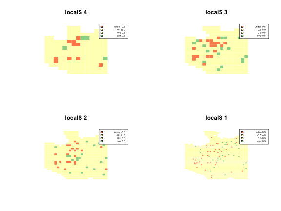

```r
statistic <- "localS" # The statistic to map

par(mfrow=c(2,2))

for (i in 4:1) {
  index <- round(length(bner.result.diff$results) / i )

  # Create the shading manually
  s <- list("breaks"=c(-0.5, 0, 0.5), "cols"=c("#fc8d59","#ffffbf", "#ffffbf","#99d594"))

  choropleth(bner.result.diff$results[[index]], bner.result.diff$results[[index]]@data[,statistic], main=paste(statistic,i),
             lty=0, shading = s)
  #points(p1, col='blue', cex=0.5)
  #points(p2, col='red',  cex=0.5)
  choro.legend("topright", sh = s, cex=0.5)
}
```

Now do *similarity* (calculated by sppt_diff)

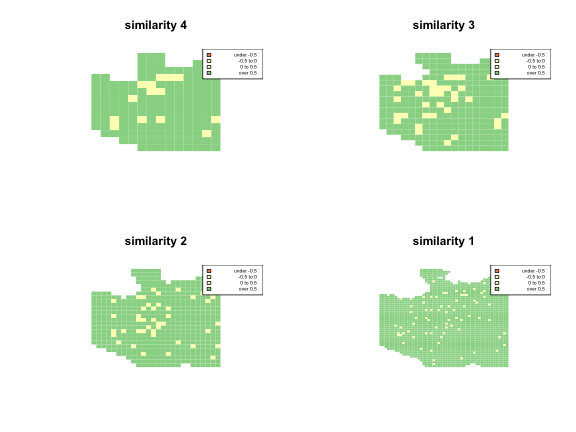

```r
statistic <- "similarity" # The statistic to map

par(mfrow=c(2,2))

for (i in 4:1) {
  index <- round(length(bner.result.diff$results) / i )

  # Create the shading manually
  s <- list("breaks"=c(-0.5, 0, 0.5), "cols"=c("#fc8d59","#ffffbf", "#ffffbf","#99d594"))

  choropleth(bner.result.diff$results[[index]], bner.result.diff$results[[index]]@data[,statistic], main=paste(statistic,i),
             lty=0, shading = s)
  #points(p1, col='blue', cex=0.5)
  #points(p2, col='red',  cex=0.5)
  choro.legend("topright", sh = s, cex=0.5)
}
```

Also do a fuzzy map of the difference in local S values.

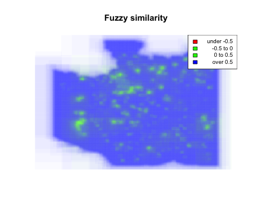

```r
# Maximum number of results we can map is 256 because transparency is represented by a two-digit hex
# I actually set this as lower otherwise it doesn't work (all the colours add up to red)
results.to.map <- NA
if (length(bner.result.diff$results) > 50) {
  results.to.map <- sample(x=1:length(bner.result.diff$results), size=50, replace = FALSE )
  print("Only mapping 50 of all grids ")
} else {
  results.to.map <- 1:(length(bner.result.diff$results)-1)
}

par(mfrow=c(1,1))
last.result <- bner.result.diff$results[[length(bner.result.diff$results)]] # Convenience for list result generated (the smallest grid)

# Shading
s.noalpha <- list("breaks"=c(-0.5, 0, 0.5),
                  #"cols"=c("#fc8d59","#ffffbf", "#ffffbf","#99d594"))
                  "cols"=c("#FF0000","#00FF00", "#00FF00","#0000FF")) # r,g, b
s         <- list("breaks"=c(-0.5, 0, 0.5),
                  #"cols"=add.alpha(c("#fc8d59","#ffffbf", "#ffffbf","#99d594"), 1/length(results.to.map)))
                  "cols"=add.alpha(c("#FF0000","#00FF00", "#00FF00","#0000FF"), 1/length(results.to.map))) # r, g, b

choropleth(
  last.result, last.result@data[,statistic], shading = s, main=paste0("Fuzzy ",statistic), lty=0
  )

for ( index in results.to.map) {
  choropleth( bner.result.diff$results[[index]], bner.result.diff$results[[index]]@data[,statistic], shading = s, lty=0, add=TRUE )
}

# For the legend, redo the shading as above but without the alpha (don't want the legend colours to be transparent)

choro.legend("topright", sh=s.noalpha, cex=0.8)
```

# Other

See if there were any warnings:

```r
warnings()
```

Save the results for mapping or whatever:

```r
# All of the R objects. Makes it easy to re-read the results
save.image("spatial_resolution2.RData")
```